# Amazon India, E-commerce Sales

#### Business Context

My client is Amazon, specifically Amazon India. The dataset I am analyzing pertains to E-commerce sales https://www.kaggle.com/datasets/thedevastator/unlock-profits-with-e-commerce-sales-data . It consists of transactional data at the order level. They are seeking a data scientist who can understand the business and propose solutions to various problems using data and business analysis tools.

Each row contains a sales record for an SKU at the order level. It is possible for an order to contain multiple SKUs; thus, a single order might have multiple records (rows), one for each SKU. The data dictionary will be presented below:

| **column name** | **description** |
| --- | --- |
| Order ID | ID of the order (string) |
| Date | Date of the sale. (Date) |
| Status | Status of the sale. (String) |
| Fulfilment | Method of fulfilment. (String) |
| Sales Channel | Channel of Sale can be Amazon or third-party ally (string) |
| ship-service-level | Type of service (string) |
| Style | Style of the product. (String) |
| SKU | Stock Keeping Unit. (String) |
| Category | Type of product. (String) |
| Size | Size of the product. (String) |
| ASIN | Amazon Standard Identification Number. (String) |
| Courier Status | Status of the courier. (String) |
| Qty | Quantity of the product. (Integer) |
| currency | The currency used for the sale. (String) |
| Amount | Amount of the sale. (Float) |
| ship-city | City of shipment (string) |
| ship-state | State of shipment (string) |
| ship-postal-code | Postal code of shipment (string) |
| ship-country | Country of shipment (string) |
| B2B | Business to business sale. (Boolean) |
| fulfilled-by | Delivery by Amazon or third-party ally (string) |

Understanding the data dictionary, some interesting columns for analysis include:

- **Fulfillment:** To evaluate the impact on orders when they are delivered by Amazon versus a third-party service.
- **Qty:** To determine the quantity of items sold per SKU.
- **Amount:** To assess sales performance.
- **Status:** To ascertain whether an order was delivered or not.
- **SKU:** To identify the item being sold.
- **Category:** To determine the category to which the SKU belongs.
- **Date:** To perform time-based analysis.

These are the following business questions that I want to answer after the analysis:

- Which are the most common SKUS that are sold together?
- Which are the most common categories that are sold together?
- Is it a good idea to have a third-party ally to deliver orders? Why?
- Is there any seasonal trend or specific behavior series analysis?
- How do the cancelled orders affect the business, and which products and categories should be enhanced?

#### Libraries & Packages

```python
import pandas as pd
import numpy as np
import datetime as dt
import seaborn as sns
import matplotlib.pyplot as plt
```

```python
# read the dataset
df = pd.read_csv('Amazon Sale Report.csv', parse_dates=['Date'])
```

```python
# do a backup of the original dataset
df_original = df.copy()
```

#### Exploring dataset

```python
# getting the shape (rows and columns)
df.shape
```

```
(128975, 24)
```

```python
# looking for some nulls values, types of column
df.info()
```

```
<class 'pandas.core.frame.DataFrame'>
RangeIndex: 128975 entries, 0 to 128974
Data columns (total 24 columns):
 #   Column              Non-Null Count   Dtype
---  ------              --------------   -----
 0   index               128975 non-null  int64
 1   Order ID            128975 non-null  object
 2   Date                128975 non-null  datetime64[ns]
 3   Status              128975 non-null  object
 4   Fulfilment          128975 non-null  object
 5   Sales Channel       128975 non-null  object
 6   ship-service-level  128975 non-null  object
 7   Style               128975 non-null  object
 8   SKU                 128975 non-null  object
 9   Category            128975 non-null  object
```

[output cut: 16 more lines]

```python
df.head()
```

|  | index | Order ID | Date | Status | Fulfilment | Sales Channel | ship-service-level | Style | SKU | Category | ... | currency | Amount | ship-city | ship-state | ship-postal-code | ship-country | promotion-ids | B2B | fulfilled-by | Unnamed: 22 |
| --- | --- | --- | --- | --- | --- | --- | --- | --- | --- | --- | --- | --- | --- | --- | --- | --- | --- | --- | --- | --- | --- |
| 0 | 0 | 405-8078784-5731545 | 2022-04-30 | Cancelled | Merchant | Amazon.in | Standard | SET389 | SET389-KR-NP-S | Set | ... | INR | 647.62 | MUMBAI | MAHARASHTRA | 400081.0 | IN | NaN | False | Easy Ship | NaN |
| 1 | 1 | 171-9198151-1101146 | 2022-04-30 | Shipped - Delivered to Buyer | Merchant | Amazon.in | Standard | JNE3781 | JNE3781-KR-XXXL | kurta | ... | INR | 406.00 | BENGALURU | KARNATAKA | 560085.0 | IN | Amazon PLCC Free-Financing Universal Merchant ... | False | Easy Ship | NaN |
| 2 | 2 | 404-0687676-7273146 | 2022-04-30 | Shipped | Amazon | Amazon.in | Expedited | JNE3371 | JNE3371-KR-XL | kurta | ... | INR | 329.00 | NAVI MUMBAI | MAHARASHTRA | 410210.0 | IN | IN Core Free Shipping 2015/04/08 23-48-5-108 | True | NaN | NaN |
| 3 | 3 | 403-9615377-8133951 | 2022-04-30 | Cancelled | Merchant | Amazon.in | Standard | J0341 | J0341-DR-L | Western Dress | ... | INR | 753.33 | PUDUCHERRY | PUDUCHERRY | 605008.0 | IN | NaN | False | Easy Ship | NaN |
| 4 | 4 | 407-1069790-7240320 | 2022-04-30 | Shipped | Amazon | Amazon.in | Expedited | JNE3671 | JNE3671-TU-XXXL | Top | ... | INR | 574.00 | CHENNAI | TAMIL NADU | 600073.0 | IN | NaN | False | NaN | NaN |

5 rows × 24 columns

```python
# get some basic statistics
df.describe()
```

|  | index | Date | Qty | Amount | ship-postal-code |
| --- | --- | --- | --- | --- | --- |
| count | 128975.000000 | 128975 | 128975.000000 | 121180.000000 | 128942.000000 |
| mean | 64487.000000 | 2022-05-12 11:49:27.951928576 | 0.904431 | 648.561465 | 463966.236509 |
| min | 0.000000 | 2022-03-31 00:00:00 | 0.000000 | 0.000000 | 110001.000000 |
| 25% | 32243.500000 | 2022-04-20 00:00:00 | 1.000000 | 449.000000 | 382421.000000 |
| 50% | 64487.000000 | 2022-05-10 00:00:00 | 1.000000 | 605.000000 | 500033.000000 |
| 75% | 96730.500000 | 2022-06-04 00:00:00 | 1.000000 | 788.000000 | 600024.000000 |
| max | 128974.000000 | 2022-06-29 00:00:00 | 15.000000 | 5584.000000 | 989898.000000 |
| std | 37232.019822 | NaN | 0.313354 | 281.211687 | 191476.764941 |

```python
# Here I look for the different values for 'ship-country'
df['ship-country'].value_counts()
# All the rows have the same value, so I will drop this column
```

```
ship-country
IN    128942
Name: count, dtype: int64
```

```python
# Here I look for the different values for 'Status'
df['Status'].value_counts()
```

```
Status
Shipped                          77804
Shipped - Delivered to Buyer     28769
Cancelled                        18332
Shipped - Returned to Seller      1953
Shipped - Picked Up                973
Pending                            658
Pending - Waiting for Pick Up      281
Shipped - Returning to Seller      145
Shipped - Out for Delivery          35
Shipped - Rejected by Buyer         11
Shipping                             8
Shipped - Lost in Transit            5
Shipped - Damaged                    1
Name: count, dtype: int64
```

```python
# Here I look for the different values for 'Courier Status'
df['Courier Status'].value_counts()
```

```
Courier Status
Shipped      109487
Unshipped      6681
Cancelled      5935
Name: count, dtype: int64
```

```python
# Verify if there are SKUS with Amount = 0
df['Amount'].min()
```

```
0.0
```

```python
# Verify if there are SKUS with Quantity = 0
df['Qty'].min()
```

```
0
```

```python
# df.to_csv('amazon_sales_report.csv', index=False)
```

```python
# Drop the following colums "promotion-ids", "Unnamed: 22" , "ship-country" because they do not add any value to the dataset
df.drop(["promotion-ids", "Unnamed: 22", "ship-country"], inplace= True, axis=1)
```

```python
# See the number or orders by month
df_grouped_month = df.groupby(df['Date'].dt.month)['Order ID'].nunique().reset_index()
df_grouped_month = df_grouped_month.rename(columns={'Order ID': '#Orders', 'Date': 'Month'})
df_grouped_month
```

|  | Month | #Orders |
| --- | --- | --- |
| 0 | 3 | 158 |
| 1 | 4 | 45858 |
| 2 | 5 | 39221 |
| 3 | 6 | 35141 |

```python
# Create a table to know which category of Status and Courier Status combination, has the highest order amount
df.groupby(['Status', 'Courier Status'])['Order ID'].nunique().reset_index()
```

|  | Status | Courier Status | Order ID |
| --- | --- | --- | --- |
| 0 | Cancelled | Cancelled | 5579 |
| 1 | Cancelled | Unshipped | 5226 |
| 2 | Pending | Cancelled | 2 |
| 3 | Pending | Shipped | 8 |
| 4 | Pending | Unshipped | 584 |
| 5 | Pending - Waiting for Pick Up | Unshipped | 262 |
| 6 | Shipped | Cancelled | 84 |
| 7 | Shipped | Shipped | 72711 |
| 8 | Shipped | Unshipped | 115 |
| 9 | Shipped - Damaged | Shipped | 1 |
| 10 | Shipped - Delivered to Buyer | Shipped | 26566 |
| 11 | Shipped - Lost in Transit | Shipped | 4 |
| 12 | Shipped - Out for Delivery | Shipped | 32 |
| 13 | Shipped - Picked Up | Shipped | 918 |
| 14 | Shipped - Rejected by Buyer | Shipped | 11 |
| 15 | Shipped - Returned to Seller | Shipped | 1851 |
| 16 | Shipped - Returning to Seller | Shipped | 130 |
| 17 | Shipping | Unshipped | 8 |

```python
# From the last table, here I calculate the percentage of orders for each combination of categories to find the more representative
df_grouped = df.groupby(['Status', 'Courier Status'])['Order ID'].nunique().reset_index()
df_grouped = df_grouped.rename(columns={'Order ID': '#Orders'})
df_grouped = df_grouped.sort_values(by=['Status', 'Courier Status', '#Orders'], ascending=[True, True, False])
df_grouped['%Orders'] = (df_grouped['#Orders'] / df['Order ID'].nunique()) * 100
df_grouped
```

|  | Status | Courier Status | #Orders | %Orders |
| --- | --- | --- | --- | --- |
| 0 | Cancelled | Cancelled | 5579 | 4.634568 |
| 1 | Cancelled | Unshipped | 5226 | 4.341325 |
| 2 | Pending | Cancelled | 2 | 0.001661 |
| 3 | Pending | Shipped | 8 | 0.006646 |
| 4 | Pending | Unshipped | 584 | 0.485138 |
| 5 | Pending - Waiting for Pick Up | Unshipped | 262 | 0.217648 |
| 6 | Shipped | Cancelled | 84 | 0.069780 |
| 7 | Shipped | Shipped | 72711 | 60.402233 |
| 8 | Shipped | Unshipped | 115 | 0.095532 |
| 9 | Shipped - Damaged | Shipped | 1 | 0.000831 |
| 10 | Shipped - Delivered to Buyer | Shipped | 26566 | 22.068817 |
| 11 | Shipped - Lost in Transit | Shipped | 4 | 0.003323 |
| 12 | Shipped - Out for Delivery | Shipped | 32 | 0.026583 |
| 13 | Shipped - Picked Up | Shipped | 918 | 0.762598 |
| 14 | Shipped - Rejected by Buyer | Shipped | 11 | 0.009138 |
| 15 | Shipped - Returned to Seller | Shipped | 1851 | 1.537656 |
| 16 | Shipped - Returning to Seller | Shipped | 130 | 0.107993 |
| 17 | Shipping | Unshipped | 8 | 0.006646 |

#### Conclusions at this point:

##### There are so many categories for Status and Courier Status, so I will only work with the most representative combination of them:

- **Status** = Cancelled and **Courier Status** = Cancelled
- **Status** = Cancelled and **Courier Status** = Unshipped
- **Status** = Shipped and **Courier Status** = Shipped
- **Status** = Shipped - Delivered to Buyer, and **Courier Status** = Shipped

##### That combination makes around 91.4% of all orders.

##### The month of March is not completed; it has only a few orders. I will work with APRIL, MAY, JUNE.

##### I will not consider SKUS that have Amount = 0 and Qty = 0.

```python
# Here I create a function to highlight only the status mentioned above
def highlight_rows(row):
    if ((row['Status'] == 'Cancelled' and row['Courier Status'] == 'Cancelled') or
        (row['Status'] == 'Cancelled' and row['Courier Status'] == 'Unshipped') or
        (row['Status'] == 'Shipped' and row['Courier Status'] == 'Shipped') or
        (row['Status'] == 'Shipped - Delivered to Buyer' and row['Courier Status'] == 'Shipped')):
        return ['background-color: #004400'] * len(row)
    else:
        return [''] * len(row)
```

```python
df_grouped_styled = df_grouped.style.apply(highlight_rows, axis=1)
df_grouped_styled
```

|  | Status | Courier Status | #Orders | %Orders |
| --- | --- | --- | --- | --- |
| 0 | Cancelled | Cancelled | 5579 | 4.634568 |
| 1 | Cancelled | Unshipped | 5226 | 4.341325 |
| 2 | Pending | Cancelled | 2 | 0.001661 |
| 3 | Pending | Shipped | 8 | 0.006646 |
| 4 | Pending | Unshipped | 584 | 0.485138 |
| 5 | Pending - Waiting for Pick Up | Unshipped | 262 | 0.217648 |
| 6 | Shipped | Cancelled | 84 | 0.069780 |
| 7 | Shipped | Shipped | 72711 | 60.402233 |
| 8 | Shipped | Unshipped | 115 | 0.095532 |
| 9 | Shipped - Damaged | Shipped | 1 | 0.000831 |
| 10 | Shipped - Delivered to Buyer | Shipped | 26566 | 22.068817 |
| 11 | Shipped - Lost in Transit | Shipped | 4 | 0.003323 |
| 12 | Shipped - Out for Delivery | Shipped | 32 | 0.026583 |
| 13 | Shipped - Picked Up | Shipped | 918 | 0.762598 |
| 14 | Shipped - Rejected by Buyer | Shipped | 11 | 0.009138 |
| 15 | Shipped - Returned to Seller | Shipped | 1851 | 1.537656 |
| 16 | Shipped - Returning to Seller | Shipped | 130 | 0.107993 |
| 17 | Shipping | Unshipped | 8 | 0.006646 |

#### Data Cleaning

```python
# Filter dataset with only april and so on
df = df[df['Date'] >= '2022-04-01']
# Filter dataset with anmount different from zero
df = df[df['Amount'] != 0]
# Filter dataset with quantity different from zero
df = df[df['Qty'] != 0]
```

```python
# Get the number of orders
df['Order ID'].nunique()
```

```
105932
```

```python
# Create the sub dataframes with the combination of status above
sub_df1 = df[(df['Status'] == 'Cancelled') & (df['Courier Status'] == 'Cancelled')]
sub_df2 = df[(df['Status'] == 'Cancelled') & (df['Courier Status'] == 'Unshipped')]
sub_df3 = df[(df['Status'] == 'Shipped') & (df['Courier Status'] == 'Shipped')]
sub_df4 = df[(df['Status'] == 'Shipped - Delivered to Buyer') & (df['Courier Status'] == 'Shipped')]

# Here I concatenate them and create a new datarame
new_df = pd.concat([sub_df1, sub_df2, sub_df3, sub_df4])
new_df.reset_index(inplace=True,drop=True)
new_df.drop(columns='index',inplace=True)

# Change the values of the column 'Status' from Shipped - Delivered to Buyer to Shipped
new_df['Status'] = new_df['Status'].replace('Shipped - Delivered to Buyer', 'Shipped')
```

#### Defining KPIs:

##### As this dataset is about e-commerce orders in India, there are some common KPI's in this business:

##### Transactional KPI's

- **#Orders**: the amount of orders; here I use the distinct count because one order can have more than one SKU.
- **Sales**: the sum of the amount. It is in "Indian rupee" currency.
- **Average order value (AOV)**: It is defined as sales/#orders. It shows, on average, the value of a ticket or purchase.
- **#Units**: The amount of units sold.
- **#Units/Order**: It shows on average how many units of one sku are sold by order.

##### Operational KPI's

- **Fill Rate**: It measures how many of the total orders have been delivered. It is defined as: Valid Orders / (Valid Orders + Cancelled Orders)

##### Defined that, the analysis will be based on the behavior of these KPI's.

##### For the transactional KPI's, I will use only the valid orders, where the status is 'Shipped', and for the operational KPI's, I will use all the datasets.

```python
# Do a copy of the new dataframe
full_df = new_df.copy()
# Filter the new dataframe with only the rows with 'Status' = 'Shipped' to the transactional analysis
df = new_df[new_df['Status'] == 'Shipped']

print(full_df.shape)
print(df.shape)
```

```
(109599, 20)
(103972, 20)
```

```python
# Create a table to view #Orders and Sales by month
df_kpis = df.groupby(df['Date'].dt.month).agg({
    'Order ID': pd.Series.nunique,
    'Amount': 'sum'
}).reset_index()

df_kpis = df_kpis.rename(columns={'Order ID': '#Orders', 'Amount': 'Sales'})

# Calculate the Average Order Value (AOV)
df_kpis['AOV'] = df_kpis['Sales'] / df_kpis['#Orders']
df_kpis
```

|  | Date | #Orders | Sales | AOV |
| --- | --- | --- | --- | --- |
| 0 | 4 | 37407 | 25664935.0 | 686.099794 |
| 1 | 5 | 32287 | 23462206.0 | 726.676557 |
| 2 | 6 | 27210 | 19753746.0 | 725.973760 |

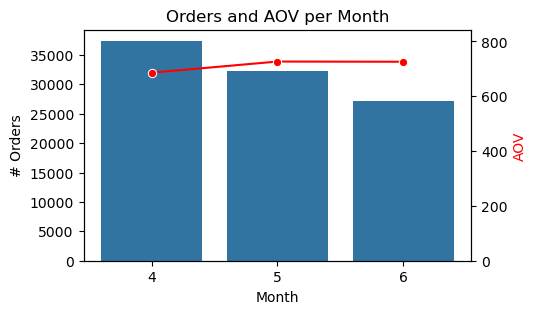

```python
# Create the figure and axis
fig, ax1 = plt.subplots(figsize=(5, 3))

# Barplot for the orders
sns.barplot(x=df_kpis['Date'].astype(str), y=df_kpis['#Orders'], ax=ax1)

# Create a second axis for the AOV
ax2 = ax1.twinx()

# Line chart for the AOV, using the same axis values as before
sns.lineplot(x=df_kpis['Date'].astype(str), y=df_kpis['AOV'], ax=ax2, marker='o', color='red')

# Additional setup
ax1.set_xlabel('Month')
ax1.set_ylabel('# Orders')
ax2.set_ylabel('AOV', color='red')
ax1.set_title('Orders and AOV per Month')

# Adjust the scale of AOV
ax2.set_ylim(0, df_kpis['AOV'].max() + 5 * df_kpis['AOV'].std())

# Show the cart
plt.show()
```

##### Insight:

##### Despite the orders level decreasing from April to May (-13.69%) and May to June (-15.72%), the AOV raised from April to May (5.91%) but almos maintained from May to June (a little decrease from 0.1%). That could mean that despite the decrease in orders, customers are spending more on one purchase.

#### Amazon vs. Merchant Analysis

##### Orders are shipped either by Amazon or by a third-party ally (called Merchant in this dataset, in the fulfillment column). So I will analyze some KPI's between each other.

```python
df_kpis_merchant = df.groupby([df['Date'].dt.month, 'Fulfilment']).agg({
    'Order ID': pd.Series.nunique,
    'Amount': 'sum'
}).reset_index()

df_kpis_merchant = df_kpis_merchant.rename(columns={'Order ID': '#Orders', 'Amount': 'Sales'})

df_kpis_merchant['AOV'] = df_kpis_merchant['Sales'] / df_kpis_merchant['#Orders']

df_kpis_merchant
```

|  | Date | Fulfilment | #Orders | Sales | AOV |
| --- | --- | --- | --- | --- | --- |
| 0 | 4 | Amazon | 26622 | 18211506.0 | 684.077304 |
| 1 | 4 | Merchant | 10785 | 7453429.0 | 691.092165 |
| 2 | 5 | Amazon | 23003 | 16530004.0 | 718.602095 |
| 3 | 5 | Merchant | 9284 | 6932202.0 | 746.682680 |
| 4 | 6 | Amazon | 21445 | 15498732.0 | 722.720075 |
| 5 | 6 | Merchant | 5765 | 4255014.0 | 738.077016 |

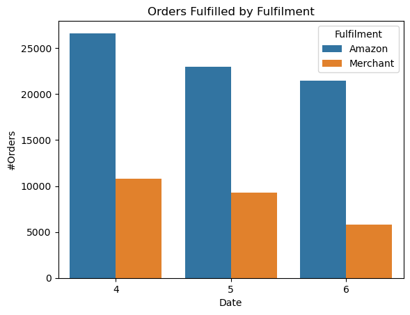

```python
# Create a barplot to show the number of orders by fulfilment column
sns.barplot(x='Date', y='#Orders', hue='Fulfilment', data=df_kpis_merchant)

# Setting the title and labels
plt.title('Orders Fulfilled by Fulfilment')
plt.xlabel('Date')
plt.ylabel('#Orders')
plt.legend(title='Fulfilment')
plt.show()
```

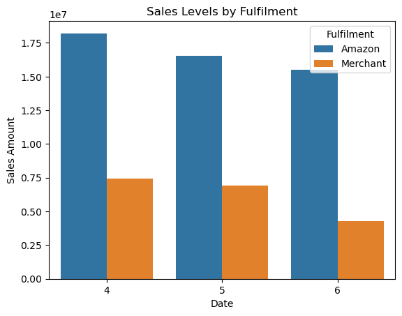

```python
# Create a barplot to show the sales by fulfilment column
sns.barplot(x='Date', y='Sales', hue='Fulfilment', data=df_kpis_merchant)

# Setting the title and labels
plt.title('Sales Levels by Fulfilment')
plt.xlabel('Date')
plt.ylabel('Sales Amount')
plt.legend(title='Fulfilment')
plt.show()
```

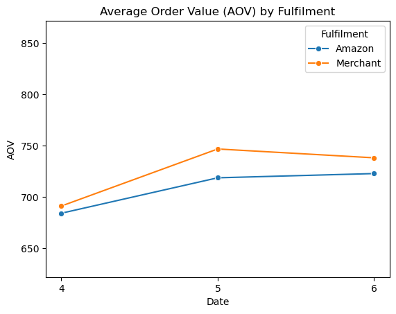

```python
# Calculate maximum AOV and standard deviation
max_aov = df_kpis_merchant['AOV'].max()
std_dev = df_kpis_merchant['AOV'].std()

# Create the line plot
# Use the 'Date' column as string to avoid the continuous axis
sns.lineplot(x=df_kpis_merchant['Date'].astype(str) , y='AOV', hue='Fulfilment', data=df_kpis_merchant, marker='o')

# Customize the chart
plt.title('Average Order Value (AOV) by Fulfilment')
plt.xlabel('Date')
plt.ylabel('AOV')
plt.legend(title='Fulfilment')

# Set y-axis limits
plt.ylim(max_aov - 5 * std_dev, max_aov + 5 * std_dev)

plt.show()
```

#### Insight:

##### Despite the proportion of orders and sales between Amazon Shipment and Merchant Shipment being almost 73% vs. 27% for each KPI, the AOV for the Merchant Shipment is 2% higher than the AOV of Amazon (721.5 vs. 706.9 for the three months). One reason could be that Merchant delivers more expensive SKUS than Amazon.

#### CROSS BASKET

##### As said before, one order can have more than one SKU, so it is important to analyze if there is any "trend" or "interaction" between SKUS. I mean, SKUS that tend to be bought together. I will do the analysis to determine if there are some SKUS that have this behavior and the same with categories.

##### SKU Cross Basket

```python
# Group by Order ID and make a list of all SKUS within that order
df_grouped_sku = df.groupby('Order ID')['SKU'].apply(lambda x: sorted(list(set(x)))).reset_index()
# Rename the columns
df_grouped_sku.columns = ['Order ID', 'SKU_LIST']
# Calulate the length of that list. Length = number of skus in that order
df_grouped_sku['SKU_LIST_LENGHT'] = df_grouped_sku['SKU_LIST'].apply(len)
# Sort the values by the lenght of the list
df_grouped_sku.sort_values('SKU_LIST_LENGHT',ascending=False, inplace=True)

# Do this because if I leave SKU_LIST as a list, it would not be possible to group by it later, so I change "," for " | "
df_grouped_sku['SKU_LIST'] = df_grouped_sku['SKU_LIST'].apply(lambda x: ' | '.join(x))
# Get the total amount of the order from the original dataset
df_grouped_sku['ORDER_AMOUNT'] = df['Amount'].groupby(df['Order ID']).transform('sum')

df_grouped_sku.reset_index(inplace=True, drop= True)

df_grouped_sku.head()
```

|  | Order ID | SKU_LIST | SKU_LIST_LENGHT | ORDER_AMOUNT |
| --- | --- | --- | --- | --- |
| 0 | 403-4984515-8861958 | J0308-DR-XXXL \| JNE3503-KR-XXXL \| JNE3633-KR-X... | 12 | 449.0 |
| 1 | 404-9932919-6662730 | J0010-LCD-XS \| J0014-LCD-XS \| JNE2100-KR-144-X... | 11 | 999.0 |
| 2 | 403-0173977-3041148 | JNE3273-KR-XXXL \| JNE3715-KR-XXXL \| JNE3720-KR... | 11 | 1338.0 |
| 3 | 408-3317403-1729937 | J0150-KR-XXXL \| JNE3437-KR-XXXL \| JNE3726-KR-X... | 10 | 372.0 |
| 4 | 171-0706521-2133101 | JNE3440-KR-N-XXL \| JNE3605-KR-XXL \| JNE3802-KR... | 9 | NaN |

```python
# Create a table for getting the KPIs for the SKU_LIST for those orders with more than 1 SKU
df_sku_list_ranking = (
    df_grouped_sku[df_grouped_sku["SKU_LIST_LENGHT"] > 1]
    .groupby(["SKU_LIST"])
    .agg(
        {"Order ID": pd.Series.nunique,
        "ORDER_AMOUNT":'sum'}
        )
    .sort_values("Order ID", ascending=False)
    .reset_index()
)

df_sku_list_ranking = df_sku_list_ranking.rename(columns= {"Order ID":"#Orders" , "ORDER_AMOUNT":"Sales"})

df_sku_list_ranking["AOV"] = df_sku_list_ranking["Sales"]/df_sku_list_ranking["#Orders"]
# Get the top 10 ranking
df_sku_list_ranking.head(10)
```

|  | SKU_LIST | #Orders | Sales | AOV |
| --- | --- | --- | --- | --- |
| 0 | SET264-KR-NP-XL \| SET268-KR-NP-XL | 6 | 3741.0 | 623.500000 |
| 1 | PJNE3252-KR-N-6XL \| PJNE3291-KR-6XL | 6 | 2962.0 | 493.666667 |
| 2 | JNE3543-KR-S \| SET397-KR-NP-S | 5 | 4501.0 | 900.200000 |
| 3 | JNE3800-KR-S \| JNE3801-KR-S | 5 | 2692.0 | 538.400000 |
| 4 | MEN5002-KR-M \| MEN5009-KR-M | 4 | 2344.0 | 586.000000 |
| 5 | MEN5009-KR-M \| MEN5011-KR-M | 4 | 3005.0 | 751.250000 |
| 6 | SET324-KR-NP-L \| SET374-KR-NP-L | 4 | 2842.0 | 710.500000 |
| 7 | JNE3543-KR-XS \| SET397-KR-NP-XS | 4 | 2886.0 | 721.500000 |
| 8 | JNE3405-KR-L \| JNE3568-KR-L | 4 | 3248.0 | 812.000000 |
| 9 | JNE3797-KR-L \| JNE3800-KR-L | 4 | 2664.0 | 666.000000 |

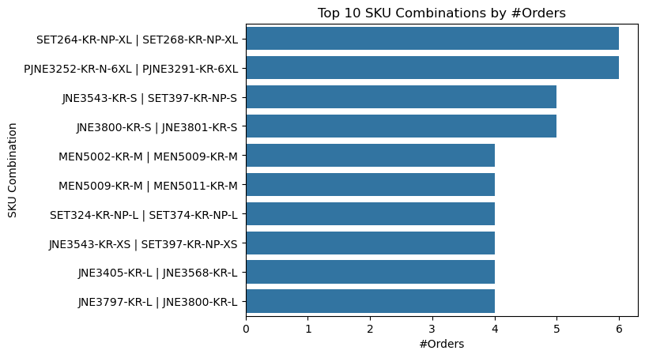

```python
# Create the barplot
sns.barplot(x=df_sku_list_ranking['#Orders'].head(10), y=df_sku_list_ranking['SKU_LIST'].head(10), orient='h')

# set title and labels
plt.title('Top 10 SKU Combinations by #Orders')
plt.xlabel('#Orders')
plt.ylabel('SKU Combination')
plt.show()
```

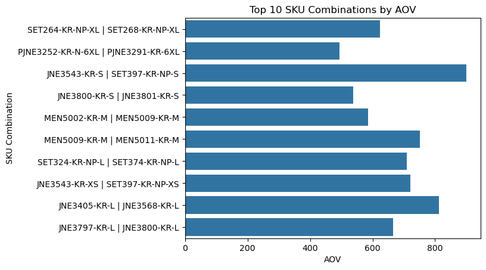

```python
# Create the barplot
sns.barplot(x=df_sku_list_ranking['AOV'].head(10), y=df_sku_list_ranking['SKU_LIST'].head(10), orient='h')

# set title and labels
plt.title('Top 10 SKU Combinations by AOV')
plt.xlabel('AOV')
plt.ylabel('SKU Combination')
plt.show()
```